# Thesis

Matthew Curran

January 15, 2020

# Data from NHANES

```
## Processing SAS dataset ALQ_I      ..
```

```
## Processing SAS dataset SLQ_I      ..
```

```
## Processing SAS dataset DEMO_I     ..
```

```
## Processing SAS dataset BMX_I      ..
```

```r
thesis_data =
  left_join(alc_data, sleep_data, by = "seqn")

thesis_data =
  left_join(thesis_data, demo_data, by = "seqn")

thesis_data =
  left_join(thesis_data, weight_data, by = "seqn")
```

```r
thesis_data_clean = thesis_data %>%
  rename(gender=riagendr, drinker=alq101, binge_drinker=alq160, apnea=slq040, age=ridageyr, race=ridreth3, martstat=dmdmartl, bmi=bmxbmi, nhanes_weights=wtmec2yr) %>%
  filter(age == 18|age == 19|age == 20|age == 21|age == 22|age == 23|age == 24) %>%
  mutate(binge_drinker=as.numeric(binge_drinker)) %>%
  mutate(binge_drinker =
         recode(binge_drinker,
           "0" = "0",
           "1" = "1", "2" = "1", "3" = "1", "4" = "1",
           "5" = "1", "6" = "1", "7" = "1", "8" = "1",
           "9" = "1", "10" = "1","11" = "1", "12" = "1",
           "13" = "1", "14" = "1", "15" = "1", "16" = "1",
           "17" = "1", "18" = "1","20" = "1",
           "777" = "Refused",
           "999" = "Don't Know"
         )) %>%
   mutate(drinker=as.numeric(drinker)) %>%
   mutate(drinker =
         recode(drinker,
           "1" = "1",
           "2" = "0",
           "7" = "Refused",
           "9" = "Don't Know"
         )) %>%
   mutate(apnea=as.numeric(apnea)) %>%
   mutate(apnea =
         recode(apnea,
           "0" = "0",
           "1" = "0",
           "2" = "1",
           "3" = "1",
           "7" = "Refused",
           "9" = "Don't Know"
         )) %>%
   mutate(gender=as.numeric(gender)) %>%
   mutate(gender =
         recode(gender,
           "1" = "1",
           "2" = "0"
         ))%>%
   mutate(race=as.numeric(race)) %>%
   mutate(race =
         recode(race,
           "1" = "Mexican American",
           "2" = "Other Race",
           "3" = "White",
           "4" = "Black",
           "6" = "Asian",
           "7" = "Other Race"
         )) %>%
   mutate(martstat=as.factor(martstat)) %>%
   mutate(martstat =
         recode(martstat,
           "1" = "1",
           "2" = "1",
           "3" = "1",
           "4" = "1",
           "5" = "0",
           "6" = "1",
           "77" = "Refused",
           "99" = "Don't Know"
         )) %>%
  filter(drinker != "Don't Know") %>%
  mutate(drinker = fct_explicit_na(drinker, na_level = "Missing")) %>%
  filter(apnea != "Don't Know") %>%
  mutate(apnea = fct_explicit_na(apnea, na_level = "Missing")) %>%
 mutate(binge_drinker = fct_explicit_na(binge_drinker, na_level = "Missing")) %>%
  mutate(age=as.numeric(age)) %>%
  mutate(martstat=as.factor(martstat)) %>%
  mutate(race=as.factor(race)) %>%
  mutate(gender=as.factor(gender)) %>%
  mutate(martstat = fct_explicit_na(martstat, na_level = "0")) %>%
  mutate(stan_nhanes_weights=
          ((nhanes_weights)/mean(nhanes_weights))
        )

summary(thesis_data_clean$stan_nhanes_weights)
```

```
##    Min. 1st Qu.  Median    Mean 3rd Qu.    Max.
##  0.1786  0.4512  0.7318  1.0000  1.2572  4.4458
```

- Mean of standardized NHANES weights is 1.00 as expected.

# Making demographic tables

```r
table_one = tableby(drinker ~age + gender + race + martstat + bmi, data=thesis_data_clean)
summary(table_one)
```

|  | 0 (N=257) | 1 (N=360) | Total (N=617) | p value |
| --- | --- | --- | --- | --- |
| **age** |  |  |  | < 0.001 |
| Mean (SD) | 19.872 (1.983) | 21.253 (1.979) | 20.677 (2.093) |  |
| Range | 18.000 - 24.000 | 18.000 - 24.000 | 18.000 - 24.000 |  |
| **gender** |  |  |  | 0.107 |
| 0 | 139 (54.1%) | 171 (47.5%) | 310 (50.2%) |  |
| 1 | 118 (45.9%) | 189 (52.5%) | 307 (49.8%) |  |
| **race** |  |  |  | < 0.001 |
| Asian | 42 (16.3%) | 29 (8.1%) | 71 (11.5%) |  |
| Black | 68 (26.5%) | 76 (21.1%) | 144 (23.3%) |  |
| Mexican American | 65 (25.3%) | 66 (18.3%) | 131 (21.2%) |  |
| Other Race | 43 (16.7%) | 69 (19.2%) | 112 (18.2%) |  |
| White | 39 (15.2%) | 120 (33.3%) | 159 (25.8%) |  |
| **martstat** |  |  |  | < 0.001 |
| 1 | 32 (12.5%) | 89 (24.7%) | 121 (19.6%) |  |
| 0 | 225 (87.5%) | 271 (75.3%) | 496 (80.4%) |  |
| **Body Mass Index (kg/m**2)** |  |  |  | 0.626 |
| N-Miss | 7 | 2 | 9 |  |
| Mean (SD) | 27.166 (7.673) | 26.874 (6.965) | 26.994 (7.260) |  |
| Range | 16.200 - 64.600 | 16.200 - 57.600 | 16.200 - 64.600 |  |

```r
table_two_data = thesis_data_clean [!(thesis_data_clean$drinker=="0"),]

table_two = tableby(binge_drinker ~age + gender + race + martstat + bmi, data=table_two_data)
summary(table_two)
```

|  | 0 (N=139) | 1 (N=72) | Missing (N=149) | Total (N=360) | p value |
| --- | --- | --- | --- | --- | --- |
| **age** |  |  |  |  | 0.582 |
| Mean (SD) | 21.388 (1.924) | 21.139 (1.952) | 21.181 (2.047) | 21.253 (1.979) |  |
| Range | 18.000 - 24.000 | 18.000 - 24.000 | 18.000 - 24.000 | 18.000 - 24.000 |  |
| **gender** |  |  |  |  | 0.004 |
| 0 | 68 (48.9%) | 22 (30.6%) | 81 (54.4%) | 171 (47.5%) |  |
| 1 | 71 (51.1%) | 50 (69.4%) | 68 (45.6%) | 189 (52.5%) |  |
| **race** |  |  |  |  | 0.333 |
| Asian | 10 (7.2%) | 7 (9.7%) | 12 (8.1%) | 29 (8.1%) |  |
| Black | 20 (14.4%) | 15 (20.8%) | 41 (27.5%) | 76 (21.1%) |  |
| Mexican American | 26 (18.7%) | 13 (18.1%) | 27 (18.1%) | 66 (18.3%) |  |
| Other Race | 29 (20.9%) | 15 (20.8%) | 25 (16.8%) | 69 (19.2%) |  |
| White | 54 (38.8%) | 22 (30.6%) | 44 (29.5%) | 120 (33.3%) |  |
| **martstat** |  |  |  |  | 0.057 |
| 1 | 39 (28.1%) | 10 (13.9%) | 40 (26.8%) | 89 (24.7%) |  |
| 0 | 100 (71.9%) | 62 (86.1%) | 109 (73.2%) | 271 (75.3%) |  |
| **Body Mass Index (kg/m**2)** |  |  |  |  | 0.207 |
| N-Miss | 1 | 1 | 0 | 2 |  |
| Mean (SD) | 27.398 (7.630) | 25.611 (5.352) | 26.991 (6.969) | 26.874 (6.965) |  |
| Range | 16.300 - 57.600 | 16.700 - 43.500 | 16.200 - 55.400 | 16.200 - 57.600 |  |

# Making imputed data sets

- Use stepAIC in stats package to check interaction terms.

```r
# Have to make binge_drinker, drinker, and apnea logical varaibles just for stepAIC, made new dataset to now affect main data.
aic_data = imputed_data_1 %>%
  mutate(binge_drinker =
         recode(binge_drinker,
           "0" = "FALSE",
           "1" = "TRUE",
           "777" = "Refused",
           "999" = "Don't Know"
         )) %>%
  mutate(drinker =
         recode(drinker,
           "0" = "FALSE",
           "1" = "TRUE",
           "7" = "Refused",
           "9" = "Don't Know"
         )) %>%
  mutate(apnea =
         recode(apnea,
           "0" = "FALSE",
           "1" = "TRUE",
           "7" = "Refused",
           "9" = "Don't Know"
         )) %>%
  mutate(binge_drinker=as.logical(binge_drinker)) %>%
  mutate(drinker=as.logical(drinker)) %>%
  mutate(apnea=as.logical(apnea))

# Best model for drinker
mult_linear_1 = lm(drinker ~ age + bmi + gender + race + martstat, data = aic_data)

interact_check = stepAIC(mult_linear_1, scope=list(upper= ~age*bmi*gender*race*martstat, lower= ~1),
        direction = c("forward"))
```

```
## Start:  AIC=-961.4
## drinker ~ age + bmi + gender + race + martstat
##
##                   Df Sum of Sq    RSS     AIC
## + bmi:race         4   2.08848 124.07 -963.70
## + age:martstat     1   0.71611 125.44 -962.92
## + bmi:martstat     1   0.48449 125.67 -961.78
## <none>                         126.15 -961.40
## + bmi:gender       1   0.29747 125.86 -960.86
## + age:gender       1   0.22104 125.93 -960.49
## + age:bmi          1   0.06295 126.09 -959.71
## + gender:martstat  1   0.04364 126.11 -959.62
## + race:martstat    4   1.21959 124.94 -959.40
## + age:race         4   1.07533 125.08 -958.68
## + gender:race      4   0.50142 125.65 -955.86
##
## Step:  AIC=-963.7
## drinker ~ age + bmi + gender + race + martstat + bmi:race
##
##                   Df Sum of Sq    RSS     AIC
## + age:martstat     1   0.72254 123.34 -965.31
## + bmi:martstat     1   0.70365 123.36 -965.21
## <none>                         124.07 -963.70
## + race:martstat    4   1.40305 122.66 -962.72
## + bmi:gender       1   0.15576 123.91 -962.48
## + age:bmi          1   0.14990 123.92 -962.45
## + age:gender       1   0.12694 123.94 -962.33
## + gender:martstat  1   0.01848 124.05 -961.79
## + age:race         4   1.16408 122.90 -961.52
## + gender:race      4   0.51184 123.55 -958.25
##
## Step:  AIC=-965.31
## drinker ~ age + bmi + gender + race + martstat + bmi:race + age:martstat
##
##                   Df Sum of Sq    RSS     AIC
## + bmi:martstat     1   0.67727 122.67 -966.70
## <none>                         123.34 -965.31
## + age:bmi          1   0.23107 123.11 -964.46
## + race:martstat    4   1.41283 121.93 -964.41
## + age:gender       1   0.16222 123.18 -964.12
```

[output cut: 17 more lines]

```
## + gender:race      4   0.52229 122.14 -961.34
##
## Step:  AIC=-966.83
## drinker ~ age + bmi + gender + race + martstat + bmi:race + age:martstat +
##     bmi:martstat + race:martstat
##
##                     Df Sum of Sq    RSS     AIC
## <none>                           121.06 -966.83
## + age:gender         1   0.10908 120.95 -965.39
## + bmi:gender         1   0.10688 120.95 -965.38
## + gender:martstat    1   0.01102 121.05 -964.89
## + age:bmi            1   0.00773 121.05 -964.87
## + gender:race        4   0.68989 120.37 -962.36
## + age:race           4   0.50777 120.55 -961.43
## + bmi:race:martstat  4   0.23639 120.82 -960.04
```

- It looks like best model is drinker ~ age + bmi + gender + race + martstat + age:martstat + bmi:martstat + bmi:race + race:martstat according to stepAIC

```r
#Limit data so non-drinkers are excluded from binge drinker analysis.
binge_data_1= aic_data [!(aic_data$drinker=="FALSE"),]

# Best model for binge_drinker
mult_linear_2 = lm(binge_drinker ~ age + bmi + gender + race + martstat, data = binge_data_1)

interact_check = stepAIC(mult_linear_2, scope=list(upper= ~age*bmi*gender*race*martstat, lower= ~1),
        direction = c("both"))
```

```
## Start:  AIC=-311.33
## binge_drinker ~ age + bmi + gender + race + martstat
##
##                   Df Sum of Sq    RSS     AIC
## - race             4   0.34294 44.646 -317.70
## - age              1   0.00239 44.305 -313.32
## - bmi              1   0.36637 44.669 -311.59
## <none>                         44.303 -311.33
## + gender:martstat  1   0.38135 43.922 -311.15
## - martstat         1   0.47128 44.774 -311.10
## + age:gender       1   0.23216 44.071 -310.44
## + age:martstat     1   0.15873 44.144 -310.09
## + race:martstat    4   1.27774 43.025 -309.50
## + bmi:martstat     1   0.02564 44.277 -309.45
## + bmi:gender       1   0.02474 44.278 -309.45
## + age:bmi          1   0.01889 44.284 -309.42
## - gender           1   1.21911 45.522 -307.60
## + age:race         4   0.24160 44.061 -304.48
## + bmi:race         4   0.04700 44.256 -303.55
## + gender:race      4   0.04463 44.258 -303.54
##
## Step:  AIC=-317.7
## binge_drinker ~ age + bmi + gender + martstat
##
##                   Df Sum of Sq    RSS     AIC
## - age              1   0.00045 44.646 -319.70
## - bmi              1   0.28277 44.929 -318.37
## + gender:martstat  1   0.42247 44.224 -317.71
## <none>                         44.646 -317.70
## + age:gender       1   0.23987 44.406 -316.84
## - martstat         1   0.62095 45.267 -316.79
## + age:martstat     1   0.16054 44.485 -316.46
## + bmi:gender       1   0.03501 44.611 -315.87
## + bmi:martstat     1   0.02640 44.620 -315.83
## + age:bmi          1   0.01409 44.632 -315.77
## - gender           1   1.25779 45.904 -313.84
## + race             4   0.34294 44.303 -311.33
##
## Step:  AIC=-319.7
## binge_drinker ~ bmi + gender + martstat
```

[output cut: 18 more lines]

```
## + bmi              1   0.28866 44.646 -319.70
## + age              1   0.00633 44.929 -318.37
## - martstat         1   1.02594 45.961 -317.58
## - gender           1   1.29567 46.231 -316.34
## + race             4   0.26466 44.670 -313.59
##
## Step:  AIC=-320.46
## binge_drinker ~ gender + martstat + gender:martstat
##
##                   Df Sum of Sq    RSS     AIC
## <none>                         44.486 -320.46
## - gender:martstat  1   0.44933 44.935 -320.34
## + bmi              1   0.25766 44.228 -319.69
## + age              1   0.01547 44.470 -318.53
## + race             4   0.24308 44.243 -313.62
```

- It looks like best model is binge_drinker ~ gender + martstat + gender:martstat according to stepAIC

```r
# Best outcome model with drinker included
mult_linear_3 = lm(apnea ~ age + bmi + gender + race + martstat + drinker, data = aic_data)

interact_check = stepAIC(mult_linear_3, scope=list(upper= ~age*bmi*gender*race*martstat*drinker, lower= ~1),
        direction = c("both"))
```

```
## Start:  AIC=-1951.66
## apnea ~ age + bmi + gender + race + martstat + drinker
##
##                    Df Sum of Sq    RSS     AIC
## + gender:martstat   1  0.221736 25.040 -1955.1
## - age               1  0.007641 25.270 -1953.5
## - drinker           1  0.014455 25.276 -1953.3
## + gender:drinker    1  0.147201 25.115 -1953.3
## - race              4  0.274673 25.537 -1953.0
## - martstat          1  0.035658 25.298 -1952.8
## - gender            1  0.070202 25.332 -1952.0
## + bmi:gender        1  0.083022 25.179 -1951.7
## <none>                          25.262 -1951.7
## + age:gender        1  0.066059 25.196 -1951.3
## - bmi               1  0.098564 25.361 -1951.3
## + martstat:drinker  1  0.060222 25.202 -1951.1
## + age:drinker       1  0.016174 25.246 -1950.1
## + bmi:drinker       1  0.009181 25.253 -1949.9
## + age:bmi           1  0.007590 25.255 -1949.8
## + age:martstat      1  0.003107 25.259 -1949.7
## + bmi:martstat      1  0.000069 25.262 -1949.7
## + race:martstat     4  0.231128 25.031 -1949.3
## + bmi:race          4  0.183876 25.078 -1948.2
## + gender:race       4  0.168171 25.094 -1947.8
## + age:race          4  0.166267 25.096 -1947.7
## + race:drinker      4  0.111442 25.151 -1946.4
##
## Step:  AIC=-1955.1
## apnea ~ age + bmi + gender + race + martstat + drinker + gender:martstat
##
##                    Df Sum of Sq    RSS     AIC
## - age               1  0.006937 25.047 -1956.9
## - race              4  0.258833 25.299 -1956.8
## - drinker           1  0.016632 25.057 -1956.7
## + gender:drinker    1  0.097562 24.943 -1955.5
## + martstat:drinker  1  0.084473 24.956 -1955.2
## <none>                          25.040 -1955.1
## - bmi               1  0.088868 25.129 -1954.9
## + bmi:gender        1  0.052026 24.988 -1954.4
## + age:drinker       1  0.020829 25.020 -1953.6
```

[output cut: 45 more lines]

```
## + bmi:martstat      1  0.000041 25.301 -1956.7
## - gender:martstat   1  0.238094 25.539 -1954.9
##
## Step:  AIC=-1960.22
## apnea ~ bmi + gender + martstat + gender:martstat
##
##                   Df Sum of Sq    RSS     AIC
## <none>                         25.321 -1960.2
## + bmi:gender       1  0.051551 25.270 -1959.5
## - bmi              1  0.114953 25.436 -1959.4
## + drinker          1  0.020105 25.301 -1958.7
## + age              1  0.007103 25.314 -1958.4
## + race             4  0.248455 25.073 -1958.3
## + bmi:martstat     1  0.000164 25.321 -1958.2
## - gender:martstat  1  0.237871 25.559 -1956.5
```

```r
# Best outcome model with binge_drinker included
mult_linear_4 = lm(apnea ~ age + bmi + gender + race + martstat + binge_drinker, data = binge_data_1)

interact_check = stepAIC(mult_linear_4, scope=list(upper= ~age*bmi*gender*race*martstat*binge_drinker, lower= ~1),
        direction = c("both"))
```

```
## Start:  AIC=-613.87
## apnea ~ age + bmi + gender + race + martstat + binge_drinker
##
##                          Df Sum of Sq     RSS     AIC
## + bmi:race                4   0.70851  9.7535 -620.66
## - martstat                1   0.00029 10.4623 -615.86
## - age                     1   0.00188 10.4639 -615.83
## - bmi                     1   0.03554 10.4976 -615.15
## <none>                                10.4620 -613.87
## - race                    4   0.43524 10.8973 -613.27
## + gender:martstat         1   0.06805 10.3940 -613.24
## + bmi:gender              1   0.06158 10.4004 -613.11
## + bmi:martstat            1   0.04584 10.4162 -612.79
## + age:binge_drinker       1   0.04208 10.4199 -612.72
## - gender                  1   0.16142 10.6234 -612.64
## + gender:race             4   0.32431 10.1377 -612.51
## + age:gender              1   0.02917 10.4329 -612.46
## + age:martstat            1   0.02676 10.4353 -612.41
## + gender:binge_drinker    1   0.01863 10.4434 -612.24
## + martstat:binge_drinker  1   0.01569 10.4463 -612.18
## + age:bmi                 1   0.01397 10.4481 -612.15
## + bmi:binge_drinker       1   0.00454 10.4575 -611.96
## - binge_drinker           1   0.25878 10.7208 -610.71
## + race:martstat           4   0.14034 10.3217 -608.72
## + age:race                4   0.13485 10.3272 -608.60
## + race:binge_drinker      4   0.06377 10.3983 -607.16
##
## Step:  AIC=-620.66
## apnea ~ age + bmi + gender + race + martstat + binge_drinker +
##     bmi:race
##
##                          Df Sum of Sq     RSS     AIC
## - age                     1   0.00425  9.7578 -622.57
## - martstat                1   0.01194  9.7655 -622.40
## <none>                                 9.7535 -620.66
## + gender:martstat         1   0.04690  9.7066 -619.68
## + age:martstat            1   0.04541  9.7081 -619.65
## + age:gender              1   0.04376  9.7098 -619.61
## + age:binge_drinker       1   0.04309  9.7104 -619.60
## + gender:race             4   0.30838  9.4451 -619.44
```

[output cut: 33 more lines]

```
## Step:  AIC=-624.17
## apnea ~ bmi + gender + race + binge_drinker + bmi:race
##
##                        Df Sum of Sq     RSS     AIC
## <none>                               9.7763 -624.17
## + gender:race           4   0.31086  9.4654 -622.99
## + bmi:gender            1   0.03007  9.7462 -622.82
## + martstat              1   0.01851  9.7578 -622.57
## - gender                1   0.17033  9.9466 -622.53
## + gender:binge_drinker  1   0.01105  9.7652 -622.41
## + age                   1   0.01082  9.7655 -622.40
## + bmi:binge_drinker     1   0.00557  9.7707 -622.29
## - binge_drinker         1   0.26817 10.0444 -620.46
## - bmi:race              4   0.68765 10.4639 -617.83
## + race:binge_drinker    4   0.06389  9.7124 -617.55
```

# Use Lapply to run prop_score for each individual dataset. Want function to save weights

```r
pscore = function(x){
ps =
  matchit(drinker ~  age + bmi + gender + race + martstat + age:martstat + bmi:martstat + bmi:race + race:martstat, data = x,
                 method = "full",
                 replace=TRUE, discard = "both",
                exact=c("gender", "martstat", "race"),
                 mahvars = c("bmi","age"),
                 caliper=.2,
                 reestimate=TRUE)

return(ps$weights)
}

prop_score = lapply (imputed_data_all, pscore)
summary(prop_score)
```

```
##      Length Class  Mode
## [1,] 617    -none- numeric
## [2,] 617    -none- numeric
## [3,] 617    -none- numeric
## [4,] 617    -none- numeric
## [5,] 617    -none- numeric
```

# Check balance of the covariates with plots

- Ran each individually

```r
#Imputed Data 1
love_test_1 = matchit(drinker ~ age + bmi + gender + race + martstat + age:martstat + bmi:martstat + bmi:race + race:martstat, data = imputed_data_1,
                 method = "full",
                 replace=TRUE, discard = "both",
                exact=c("gender", "martstat", "race"),
                 mahvars = c("bmi","age"),
                 caliper=.2,
                 reestimate=FALSE)
```

```
## Note: s.d.denom not specified; assuming pooled.
```

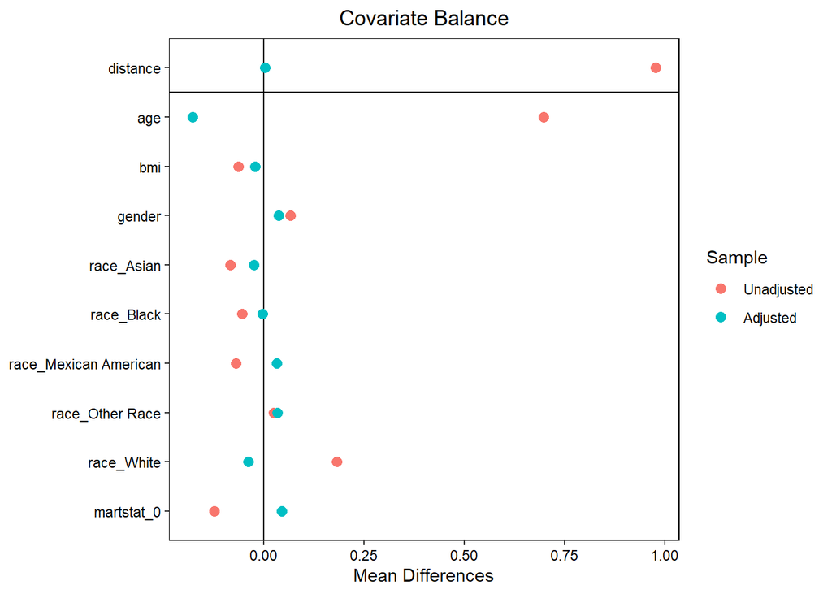

```r
love.plot(love_test_1)
```

```r
#Imputed Data 2
love_test_2 = matchit(drinker ~ age + bmi + gender + race + martstat + age:martstat + bmi:martstat + bmi:race + race:martstat, data = imputed_data_2,
                 method = "full",
                 replace=TRUE, discard = "both",
                exact=c("gender", "martstat", "race"),
                 mahvars = c("bmi","age"),
                 caliper=.2,
                 reestimate=FALSE)
```

```
## Note: s.d.denom not specified; assuming pooled.
```

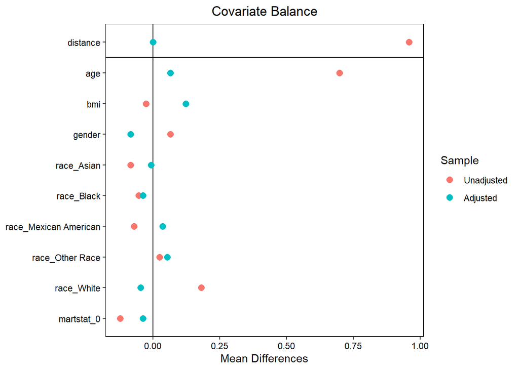

```r
love.plot(love_test_2)
```

```r
#Imputed Data 3
love_test_3 = matchit(drinker ~ age + bmi + gender + race + martstat + age:martstat + bmi:martstat + bmi:race + race:martstat, data = imputed_data_3,
                 method = "full",
                 replace=TRUE, discard = "both",
                exact=c("gender", "martstat", "race"),
                 mahvars = c("bmi","age"),
                 caliper=.2,
                 reestimate=FALSE)
```

```
## Note: s.d.denom not specified; assuming pooled.
```

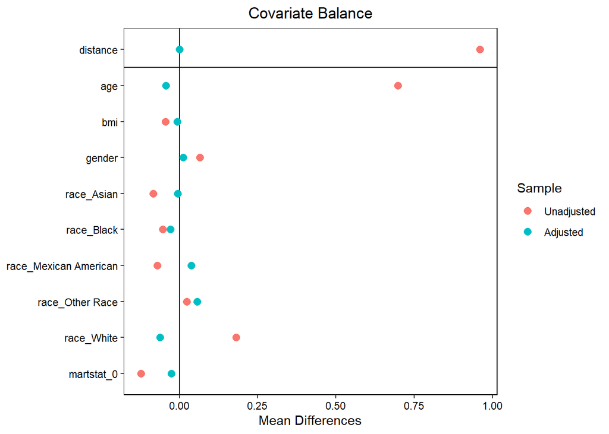

```r
love.plot(love_test_3)
```

```r
#Imputed Data 4
love_test_4 = matchit(drinker ~ age + bmi + gender + race + martstat + age:martstat + bmi:martstat + bmi:race + race:martstat, data = imputed_data_4,
                 method = "full",
                 replace=TRUE, discard = "both",
                exact=c("gender", "martstat", "race"),
                 mahvars = c("bmi","age"),
                 caliper=.2,
                 reestimate=FALSE)
```

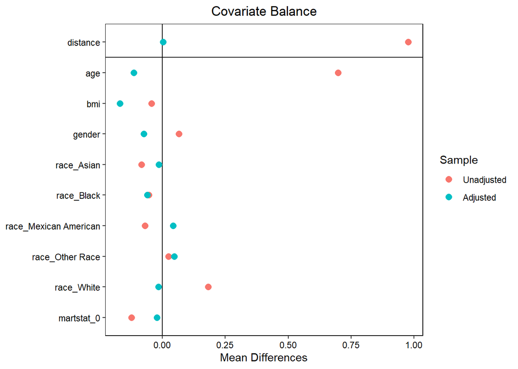

```r
love.plot(love_test_4)
```

```r
#Imputed Data 5
love_test_5 = matchit(drinker ~ age + bmi + gender + race + martstat + age:martstat + bmi:martstat + bmi:race + race:martstat, data = imputed_data_5,
                 method = "full",
                 replace=TRUE, discard = "both",
                exact=c("gender", "martstat", "race"),
                 mahvars = c("bmi","age"),
                 caliper=.2,
                 reestimate=FALSE)
```

```
## Note: s.d.denom not specified; assuming pooled.
```

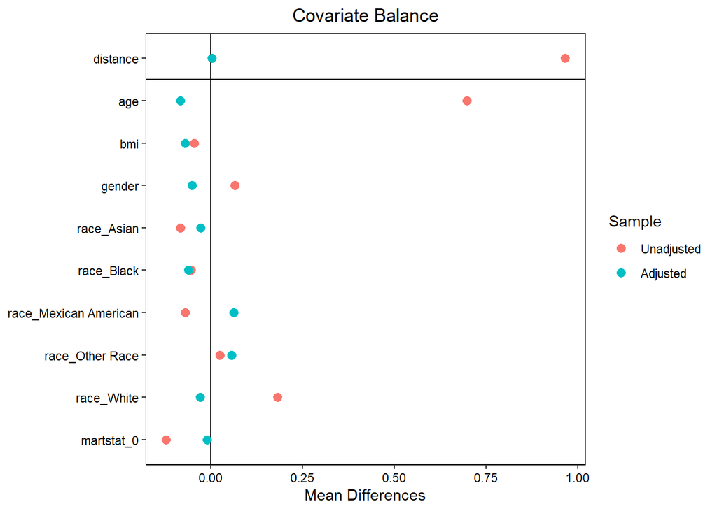

```r
love.plot(love_test_5)
```

# Checking the balance of propensity score weight times standardized NHANES weights to see if any need to be truncated

```r
weight_plot1 = thesis_data_clean %>%
  mutate (stand_weight =
           ((prop_score[[3]])*(stan_nhanes_weights))
          )

summary(weight_plot1$stand_weight)
```

```
##    Min. 1st Qu.  Median    Mean 3rd Qu.    Max.
##  0.0000  0.3099  0.6545  1.1907  1.2396 46.6030
```

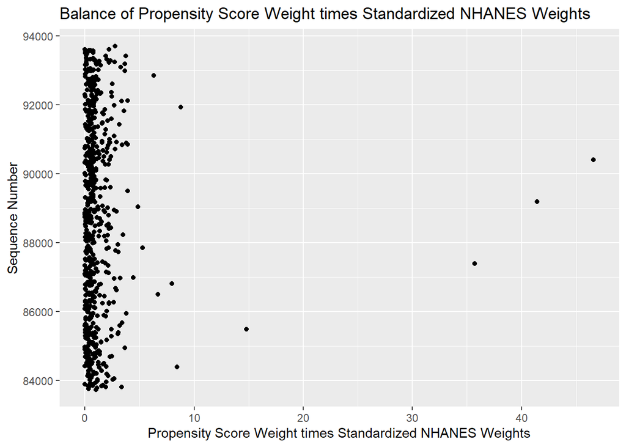

```r
 ggplot(data = weight_plot1,aes(x=stand_weight,y=seqn))+
  geom_point()+
  labs(
    title = "Balance of Propensity Score Weight times Standardized NHANES Weights",
    x = "Propensity Score Weight times Standardized NHANES Weights",
    y ="Sequence Number"
  )
```

```r
weight_plot2 = thesis_data_clean %>%
  mutate (stand_weight =
           ((prop_score[[3]])*(stan_nhanes_weights))
          ) %>%
 mutate(weight_trunc = pmin(pmax(stand_weight, quantile(stand_weight, .00)),
                                          quantile(stand_weight, .99)))

  summary(weight_plot2$weight_trunc)
```

```
##    Min. 1st Qu.  Median    Mean 3rd Qu.    Max.
##  0.0000  0.3099  0.6545  1.0136  1.2396  7.7789
```

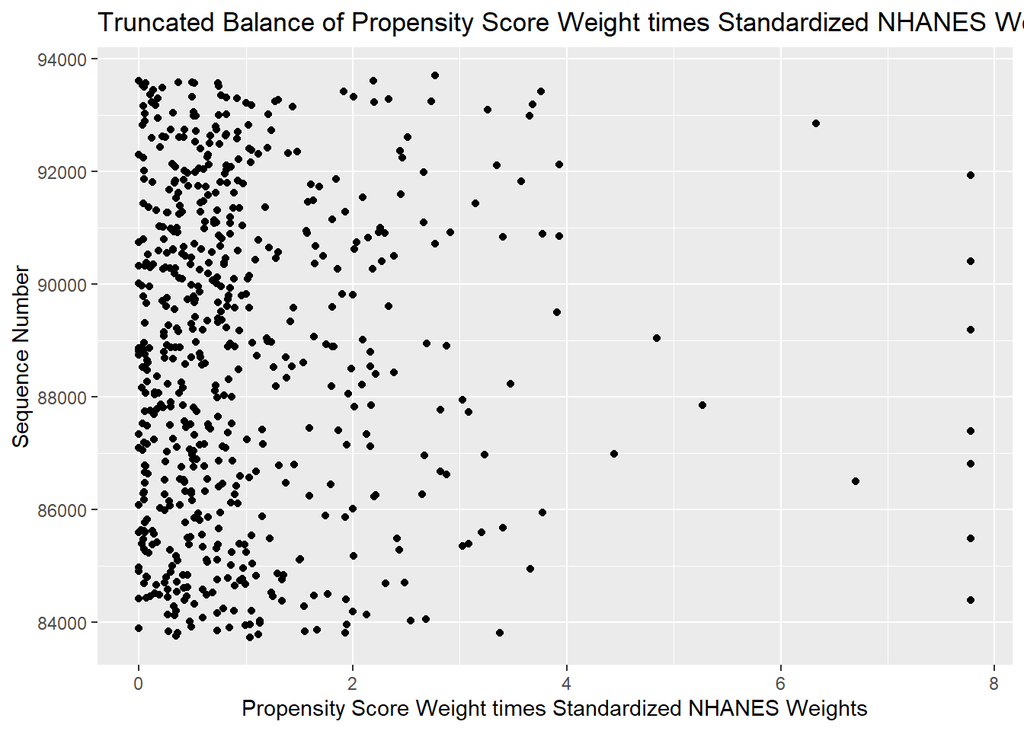

```r
  ggplot(data = weight_plot2, aes(x=weight_trunc,y=seqn))+
  geom_point()+
  labs(
    title = "Truncated Balance of Propensity Score Weight times Standardized NHANES Weights",
    x = "Propensity Score Weight times Standardized NHANES Weights",
    y ="Sequence Number"
  )
```

# GLM using weights for the outcome model with drinker, for each imputed data set. Included variables from stepAIC and any other variables that logically should be included.

```r
outcome_fun = function(z){
outcome_fun_1 = function(y) {
z = z %>%
  mutate (stand_weight =
           ((y)*(stan_nhanes_weights))
          ) %>%
 mutate(weight_trunc = pmin(pmax(stand_weight, quantile(stand_weight, .00)),
                                          quantile(stand_weight, .99)))

outcome_lm_1 = glm(apnea ~ bmi + age + gender + race + martstat + drinker + gender:martstat, family = quasibinomial(), data=z, weights= (y*((nhanes_weights)/mean(nhanes_weights))))
}

outcome_1 = lapply(prop_score, outcome_fun_1)

summary(MIcombine(outcome_1))

}

outcome_all = lapply(imputed_data_all, outcome_fun)
```

```
## Multiple imputation results:
##       MIcombine.default(outcome_1)
##                          results         se       (lower       upper) missInfo
## (Intercept)          -8.46144039 4.30723905 -16.91642428 -0.006456502      7 %
## bmi                   0.01941039 0.03099592  -0.04134075  0.080161543      0 %
## age                   0.06946678 0.15469803  -0.23437126  0.373304821      9 %
## gender1               3.15153891 1.50127498   0.20878632  6.094291492      2 %
## raceBlack             0.62204957 1.77278949  -2.85255544  4.096654590      0 %
## raceMexican American  1.52845079 1.74889536  -1.89949326  4.956394846      1 %
## raceOther Race        1.44813274 1.71596160  -1.91509023  4.811355709      0 %
## raceWhite            -0.43656937 1.72640819  -3.82027624  2.947137507      0 %
## martstat0             1.93972368 1.53452410  -1.06812155  4.947568915      2 %
## drinker1              0.73743696 0.63089800  -0.50977921  1.984653127     18 %
## gender1:martstat0    -2.89240704 1.62871029  -6.08493150  0.300117416      2 %
## Multiple imputation results:
##       MIcombine.default(outcome_1)
##                          results         se       (lower      upper) missInfo
## (Intercept)          -8.51925838 4.29669876 -16.95483065 -0.08368611      8 %
## bmi                   0.02299008 0.03123716  -0.03824265  0.08422281      2 %
## age                   0.06817288 0.15400089  -0.23432646  0.37067221      9 %
## gender1               3.14831100 1.49571202   0.21645207  6.08016993      2 %
## raceBlack             0.61136488 1.76588979  -2.84971646  4.07244623      0 %
## raceMexican American  1.51518824 1.74182658  -1.89890841  4.92928489      1 %
## raceOther Race        1.43657191 1.70906517  -1.91313435  4.78627816      0 %
## raceWhite            -0.42904966 1.71802597  -3.79632623  2.93822690      0 %
## martstat0             1.93912293 1.52838940  -1.05669642  4.93494228      2 %
## drinker1              0.72064690 0.62284344  -0.50968165  1.95097545     17 %
## gender1:martstat0    -2.87278025 1.62463122  -6.05737125  0.31181076      2 %
## Multiple imputation results:
##       MIcombine.default(outcome_1)
##                          results         se       (lower      upper) missInfo
## (Intercept)          -8.54623797 4.30351578 -16.99553971 -0.09693623      8 %
## bmi                   0.02328104 0.03116643  -0.03781298  0.08437506      2 %
## age                   0.06891494 0.15402115  -0.23362971  0.37145959      9 %
## gender1               3.14779844 1.49586000   0.21565085  6.07994603      2 %
## raceBlack             0.61352815 1.76593174  -2.84763556  4.07469185      0 %
## raceMexican American  1.51413122 1.74187911  -1.90006482  4.92832726      1 %
## raceOther Race        1.43637060 1.70915084  -1.91350358  4.78624477      0 %
## raceWhite            -0.42879323 1.71815708  -3.79632683  2.93874036      0 %
## martstat0             1.94075113 1.52846860  -1.05521894  4.93672120      2 %
```

[output cut: 15 more lines]

```
## gender1:martstat0    -2.87044485 1.62393528  -6.05367417  0.31278448      2 %
## Multiple imputation results:
##       MIcombine.default(outcome_1)
##                          results         se       (lower      upper) missInfo
## (Intercept)          -8.54084682 4.31951772 -17.02132445 -0.06036918      8 %
## bmi                   0.02171857 0.03113505  -0.03930699  0.08274414      1 %
## age                   0.07033073 0.15450423  -0.23316555  0.37382700      9 %
## gender1               3.14965419 1.49884552   0.21166295  6.08764543      2 %
## raceBlack             0.61705122 1.76982147  -2.85173653  4.08583897      0 %
## raceMexican American  1.52119389 1.74523539  -1.89956690  4.94195468      1 %
## raceOther Race        1.44183850 1.71289198  -1.91536816  4.79904515      0 %
## raceWhite            -0.43287903 1.72244276  -3.80881318  2.94305513      0 %
## martstat0             1.94311507 1.53171350  -1.05921222  4.94544237      2 %
## drinker1              0.73039526 0.62793113  -0.51083139  1.97162192     18 %
## gender1:martstat0    -2.88280291 1.62678886  -6.07157850  0.30597268      2 %
```

# GLM using weights for the outcome model with binge drinking, for each imputed data set. Included variables from stepAIC and any other variables that logically should be included.

```r
#create a list from imputed data to exclude non-drinkers
create_binge_data = function(b){
  binge_data_list = b[!(b$drinker=="0"),]
}

binge_data_all = lapply(imputed_data_all, create_binge_data)

#Weights for binge drinkers
pscore_binge = function(x){
ps_binge = matchit(binge_drinker ~ age + bmi + race + gender + martstat + gender:martstat, data = x,
                 method = "full",
                 replace=TRUE, discard = "both",
                exact=c("gender", "martstat", "race"),
                 mahvars = c("bmi","age"),
                 caliper=.2,
                 reestimate=TRUE)

return(ps_binge$weights)
}

prop_score_binge = lapply (binge_data_all, pscore_binge)
#outcomes with binge drinking
outcome_fun_binge = function(z){
outcome_fun_binge = function(y) {

  z = z %>%
  mutate (stand_weight =
           ((y)*(stan_nhanes_weights))
          ) %>%
 mutate(weight_trunc = pmin(pmax(stand_weight, quantile(stand_weight, .00)),
                                          quantile(stand_weight, .99)))

outcome_lm_binge =
  glm(apnea ~ age + bmi + race + martstat + gender + binge_drinker + bmi:race, family = quasibinomial(), data=z, weights= (y*((nhanes_weights)/mean(nhanes_weights))))
}

outcome_1 = lapply(prop_score_binge, outcome_fun_binge)

summary(MIcombine(outcome_1))

}

outcome_all_binge = lapply(binge_data_all, outcome_fun_binge)
```

```
## Multiple imputation results:
##       MIcombine.default(outcome_1)
##                                results           se        (lower       upper)
## (Intercept)              -287.94263826 7.847873e+04 -1.541034e+05 1.535275e+05
## age                        -0.18893759 3.710939e-01 -9.163081e-01 5.384330e-01
## bmi                         8.54980275 2.319747e+03 -4.538071e+03 4.555171e+03
## raceBlack                 309.44023337 7.847873e+04 -1.535060e+05 1.541249e+05
## raceMexican American      281.67023114 7.847873e+04 -1.535338e+05 1.540972e+05
## raceOther Race            284.98013901 7.847873e+04 -1.535305e+05 1.541005e+05
## raceWhite                 290.18030084 7.847873e+04 -1.535253e+05 1.541057e+05
## martstat0                   0.05027227 1.948941e+00 -3.769596e+00 3.870141e+00
## gender1                     2.27042991 2.533676e+00 -2.698911e+00 7.239770e+00
## binge_drinker1             -2.23918687 2.258267e+00 -6.665362e+00 2.186989e+00
## binge_drinkerMissing                NA           NA            NA           NA
## bmi:raceBlack              -9.47777507 2.319747e+03 -4.556099e+03 4.537143e+03
## bmi:raceMexican American   -8.37731196 2.319747e+03 -4.554998e+03 4.538244e+03
## bmi:raceOther Race         -8.40882235 2.319747e+03 -4.555030e+03 4.538212e+03
## bmi:raceWhite              -8.76730417 2.319747e+03 -4.555388e+03 4.537854e+03
##                          missInfo
## (Intercept)                   0 %
## age                           1 %
## bmi                           0 %
## raceBlack                     0 %
## raceMexican American          0 %
## raceOther Race                0 %
## raceWhite                     0 %
## martstat0                     0 %
## gender1                       5 %
## binge_drinker1                1 %
## binge_drinkerMissing         NA %
## bmi:raceBlack                 0 %
## bmi:raceMexican American      0 %
## bmi:raceOther Race            0 %
## bmi:raceWhite                 0 %
## Multiple imputation results:
##       MIcombine.default(outcome_1)
##                                results           se        (lower       upper)
## (Intercept)              -288.39204052 7.850210e+04 -1.541497e+05 1.535729e+05
## age                        -0.18816883 3.699424e-01 -9.132806e-01 5.369429e-01
## bmi                         8.56207457 2.320395e+03 -4.539329e+03 4.556453e+03
```

[output cut: 115 more lines]

```
## (Intercept)                   0 %
## age                           1 %
## bmi                           0 %
## raceBlack                     0 %
## raceMexican American          0 %
## raceOther Race                0 %
## raceWhite                     0 %
## martstat0                     0 %
## gender1                       5 %
## binge_drinker1                1 %
## binge_drinkerMissing         NA %
## bmi:raceBlack                 0 %
## bmi:raceMexican American      0 %
## bmi:raceOther Race            0 %
## bmi:raceWhite                 0 %
```